# CS5801 Coursework Template Proforma

2348513

04 January, 2024

# 0. Instructions

```r
# Add code here to load all the required libraries with `library()`.
# Do not include any `install.package()` for any required packages in this rmd file.
install.packages("Hmisc")
install.packages("stringdist")
install.packages("corrplot")
install.packages("knitr")
install.packages("kableExtra")
install.packages("formattable")
install.packages("DT")
install.packages("tibble")
install.packages("skimr")
install.packages("caret")
install.packages("robustbase")
library(robustbase)
library(skimr)
library(forcats)
library(knitr)
library(tibble)
library(kableExtra)
library(formattable)
library(DT)
library(corrplot)
library(Hmisc) #for median
library(stringdist)
library(ggplot2)
library(dplyr)
library(tidyr)
library(caret)
library(randomForest)
library(tree)
```

# 1. Organise and clean the data

## 1.1 Subset the data into the specific dataset allocated

```r
# Only change the value for SID
# Assign your student id into the variable SID, for example:
SID <- 2348513                  # This is an example, replace 2101234 with your actual ID
SIDoffset <- (SID %% 50) + 1    # Your SID mod 50 + 1
View(cars.analysis)

setwd("C:/Users/SLL807/Desktop/Assignment")

load("car-analysis-data.Rda")
# Now subset the car data set
# Pick every 50th observation starting from your offset
# Put into your data frame named mydf (you can rename it)
mydf <- cars.analysis[seq(from=SIDoffset,to=nrow(cars.analysis),by=50),]
```

## 1.2 Data quality analysis plan

1- Summary Statistics: Use functions like summary(), str(), head(), and tail() to get an overview data

2- Missing Values: identify missing values by is.na() func

3- Data Imputation: impute() to fill mising values

4- Duplicates: finding duplicates by unique()

5- Data Types: each column must have correct data type (class()) else convert them e.g as.numeric()

6- Data Normalization: by == if duplicates found like my or My

7- Outlier Detection: by boxplots and removal (if unlikely)

8- Correlation Analysis: Evaluate correlations corr() between numeric variables for dependencies/multicollinearity.

9- Data Distribution: Visualize data distributions with histograms, boxplots, or ggplot2

10- Descriptive Statistics: Calculate descriptive statistics for numerical variables to understand their central tendencies and variability by summary() and other func

11- Documentation and Reporting: Document all findings, transformations, and decisions clearly

12- Data Consistency and Domain-Specific Checks: Assess consistency between related columns to ensure coherence and logical relationships.

13- Cross-Field Validation: Validate relationships between different fields to ensure coherence.

14- Documentation and Reporting: Document all findings, transformations, and decisions.

## 1.3 Data quality analysis findings

1. Summary Statistics

```r
# 1. Summary func to check the data set
print("Checking Summary Statisctics to gret to know the dataset")
```

```
[1] "Checking Summary Statisctics to gret to know the dataset"
```

```r
cat("\n")
```

```r
summary_table <- summary(mydf)

# Convert summary output to an HTML table with specified styling for all rows
summary_table_html <- kable(summary_table, digits = 2, format = "html") %>%
  kable_styling(full_width = FALSE) %>%
  row_spec(0:nrow(summary_table), background = "#000000", color = "#FFFFFF")

summary_table_html
```

|  | brand | year | mileage | engine_size | automatic_transmission | fuel | drivetrain | min_mpg | max_mpg | damaged | first_owner | navigation_system | bluetooth | third_row_seating | heated_seats | price |
| --- | --- | --- | --- | --- | --- | --- | --- | --- | --- | --- | --- | --- | --- | --- | --- | --- |
|  | Length:410 | Min. :1953 | Min. : 0 | Min. :1.200 | Min. :0.0000 | Length:410 | Length:410 | Min. : 0.00 | Min. :-30.00 | Min. :0.0000 | Min. :0.0000 | Min. :0.0000 | Min. :0.0000 | Min. :0.0000 | Min. :0.0000 | Min. : 5850 |
|  | Class :character | 1st Qu.:2015 | 1st Qu.: 21328 | 1st Qu.:2.000 | 1st Qu.:1.0000 | Class :character | Class :character | 1st Qu.:18.00 | 1st Qu.: 24.00 | 1st Qu.:0.0000 | 1st Qu.:0.0000 | 1st Qu.:0.0000 | 1st Qu.:1.0000 | 1st Qu.:0.0000 | 1st Qu.:0.0000 | 1st Qu.:18991 |
|  | Mode :character | Median :2019 | Median : 43286 | Median :2.400 | Median :1.0000 | Mode :character | Mode :character | Median :21.00 | Median : 28.00 | Median :0.0000 | Median :1.0000 | Median :0.0000 | Median :1.0000 | Median :0.0000 | Median :0.0000 | Median :28512 |
|  | NA | Mean :2017 | Mean : 48382 | Mean :2.663 | Mean :0.9195 | NA | NA | Mean :21.42 | Mean : 28.15 | Mean :0.2334 | Mean :0.5037 | Mean :0.4439 | Mean :0.8707 | Mean :0.0878 | Mean :0.4341 | Mean :28399 |
|  | NA | 3rd Qu.:2021 | 3rd Qu.: 66593 | 3rd Qu.:3.400 | 3rd Qu.:1.0000 | NA | NA | 3rd Qu.:25.00 | 3rd Qu.: 32.00 | 3rd Qu.:0.0000 | 3rd Qu.:1.0000 | 3rd Qu.:1.0000 | 3rd Qu.:1.0000 | 3rd Qu.:0.0000 | 3rd Qu.:1.0000 | 3rd Qu.:37564 |
|  | NA | Max. :2023 | Max. :190312 | Max. :6.400 | Max. :1.0000 | NA | NA | Max. :89.00 | Max. :100.00 | Max. :1.0000 | Max. :1.0000 | Max. :1.0000 | Max. :1.0000 | Max. :1.0000 | Max. :1.0000 | Max. :54995 |
|  | NA | NA | NA | NA's :20 | NA | NA | NA | NA's :55 | NA's :55 | NA's :3 | NA's :7 | NA | NA | NA | NA | NA |

```r
str(mydf)
```

```
'data.frame':   410 obs. of  16 variables:
 $ brand                 : chr  "Audi" "Kia" "Ford" "Jeep" ...
 $ year                  : num  2022 2021 2021 2022 2019 ...
 $ mileage               : num  7232 60942 45701 2963 47587 ...
 $ engine_size           : num  2 1.6 3 3.6 2 5.6 2 3.6 1.6 2 ...
 $ automatic_transmission: num  1 1 1 1 1 1 1 1 1 1 ...
 $ fuel                  : chr  "Petrol" "Petrol" "Petrol" "Petrol" ...
 $ drivetrain            : chr  "Four-wheel Drive" "Front-wheel Drive" "Four-wheel Drive" "Four-wheel Drive" ...
 $ min_mpg               : num  28 27 18 21 22 13 0 17 22 24 ...
 $ max_mpg               : num  36 37 24 29 29 18 14 25 25 33 ...
 $ damaged               : num  0 1 0 0 0 0 0 1 0 0 ...
 $ first_owner           : num  1 1 1 1 1 1 1 1 0 1 ...
 $ navigation_system     : num  0 0 1 0 0 1 0 1 1 0 ...
 $ bluetooth             : num  1 1 1 0 1 1 1 1 1 1 ...
 $ third_row_seating     : num  0 0 1 0 0 1 0 0 0 0 ...
 $ heated_seats          : num  1 0 1 0 0 0 0 0 1 0 ...
 $ price                 : num  37500 15990 46290 44290 28990 ...
```

2. Checked for missing entries by is.na()

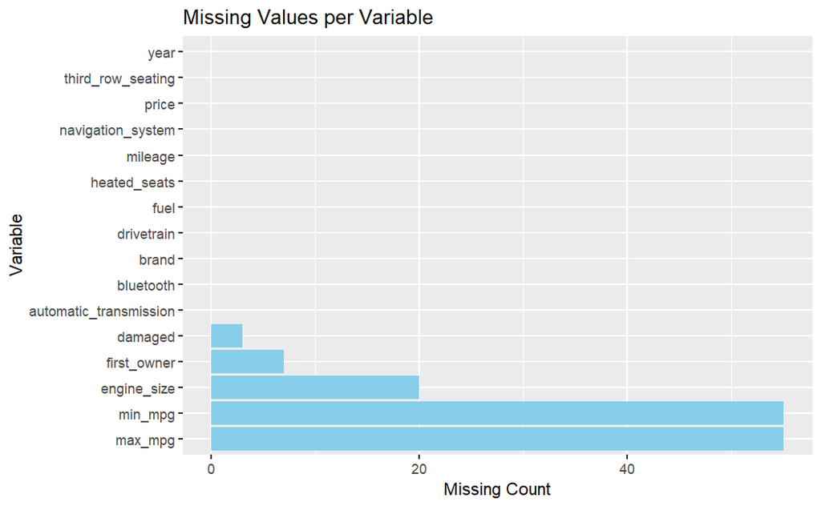

```r
# 2. Check for missing values in all columns

missing_values <- colSums(is.na(mydf))
missing_df <- data.frame(variable = names(missing_values), missing_count = missing_values)
missing_df <- missing_df[order(-missing_df$missing_count), ]  # Sort by missing count

# Visualize missing values
ggplot(data = missing_df, aes(x = reorder(variable, -missing_count), y = missing_count)) +
  geom_bar(stat = "identity", fill = "skyblue") +
  coord_flip() +
  labs(title = "Missing Values per Variable", x = "Variable", y = "Missing Count")
```

```r
missing_values <- colSums(is.na(mydf))
#missing #issue 1 found: missing values
if(any(missing_values)){
  print("Rows contain NA. Imputating NA with Column Median")
}
```

```
[1] "Rows contain NA. Imputating NA with Column Median"
```

3. Impute NA with median of the column.

```r
# 3. Solving missing values by imputate
for (col in names(mydf)) {
  # Check if the column has missing values
  if (any(is.na(mydf[[col]]))) {
    # Calculate median of the column excluding NA values
    col_median <- median(mydf[[col]], na.rm = TRUE)

    # Replace NA values with the median
    mydf[[col]][is.na(mydf[[col]])] <- col_median
  }
}
```

4. Checked/removed duplicated rows by dupicated().

```r
# 4. Finding data duplicated ROWS
duplicate_rows <- mydf[duplicated(mydf), ]

if(nrow(duplicate_rows)>0){
  print("Duplicate rows found")
  print(duplicate_rows)
  } else{
  print("No Duplicate Rows Found")
  }
```

```
[1] "No Duplicate Rows Found"
```

5. Data Types checking and Removal by unique() and converted chars to factors as needed.

```r
# 5. Correcting Data Types by looking at str() and unique() result:

# brand, automatic_transmission, fuel, drivetrain, damaged, first_owner, navigation_system, bluetooth, third_row_seating, heated_seats are ALL CATEGORICAL
mydf$brand <- as.factor(mydf$brand)
mydf$automatic_transmission <- as.factor(mydf$automatic_transmission)
mydf$fuel <- as.factor(mydf$fuel)
mydf$drivetrain <- as.factor(mydf$drivetrain)
mydf$damaged <- as.factor(mydf$damaged)
mydf$first_owner <- as.factor(mydf$first_owner)
mydf$navigation_system <- as.factor(mydf$navigation_system)
mydf$bluetooth <- as.factor(mydf$bluetooth)
mydf$third_row_seating <- as.factor(mydf$third_row_seating)
mydf$heated_seats <- as.factor(mydf$heated_seats)


##########################################
```

6. Checked/Corrected Data Consistency and Domain-Specific Checks for discrepancies and applied Data Normalization e.g negative values, spelling mistakes etc

```r
# 6. Performing Data Normalization/Data Consistency (e.g My==my)
#Issues found:
#(ii). Pertol==Petrol in fuel

mydf$fuel <- fct_collapse(mydf$fuel, Petrol = c("Pertol", "Petrol"))


#(ii). Unknown values should be left as it is for transparency.

#(iii). Here, numerical cols such as Price, max_mpg, min_mpg and mileage can never be negative
mydf$year <- abs(mydf$year)
mydf$mileage <- abs(mydf$mileage)
mydf$engine_size <- abs(mydf$engine_size)
mydf$min_mpg <- abs(mydf$min_mpg)
mydf$max_mpg <- abs(mydf$max_mpg)
mydf$price <- abs(mydf$price)

#(iv). ignore if
           # (i) mileage>0 but max_mpg & min_mpg=0, assume car is not working
           # (ii)mileage=0 but max_mpg and min_mpg>0, assume max and min mpg is taken as commonly seen mpgs.
#(v). max_mpg>min_mpg else imputate from that car rows

#(vi) DATA CONSISTENCY CHECKS

#Check if 'year' values are within a reasonable range
invalid_years <- mydf$year < 1900 | mydf$year > 2050

# Check for negative mileage or unrealistically high values
invalid_mileage <- mydf$mileage < 0 | mydf$mileage > 500000

# Check for engine sizes that seem unrealistic
invalid_engine_size <- mydf$engine_size <= 0 | mydf$engine_size > 100

# Check for values outside expected range for min and max MPG
invalid_min_max_mpg <- mydf$min_mpg < 0 | mydf$max_mpg < 0 | mydf$min_mpg > mydf$max_mpg

# Check if 'price' values are negative or too high
invalid_price <- mydf$price < 0 | mydf$price > 1e6

# Check for inconsistencies between boolean columns (should be 0 or 1)
invalid_boolean_columns <- mydf[, c("automatic_transmission", "damaged", "first_owner",
                                    "navigation_system", "bluetooth", "third_row_seating",
                                    "heated_seats")]
invalid_boolean_columns <- invalid_boolean_columns !=0 & invalid_boolean_columns != 1

inconsistency_matrix <- cbind(
  as.integer(invalid_years),
  as.integer(invalid_mileage),
  as.integer(invalid_engine_size),
  as.integer(invalid_min_max_mpg),
  as.integer(invalid_price),
  as.integer(rowSums(invalid_boolean_columns))
)

# Identify rows with any inconsistencies
inconsistent_rows <- which(rowSums(inconsistency_matrix) > 0)

# Display rows with inconsistencies
if (length(inconsistent_rows) > 0) {
  print("Inconsistent rows:")
  print(mydf[inconsistent_rows, ])
} else {
  print("No inconsistencies found.")
}
```

```
[1] "No inconsistencies found."
```

```r
print(unique(mydf$fuel))
```

```
[1] Petrol   GPL      Hybrid   Unknown  Electric Diesel
Levels: Diesel Electric GPL Hybrid Petrol Unknown
```

7.Data visualisations for both categorical and numeric data

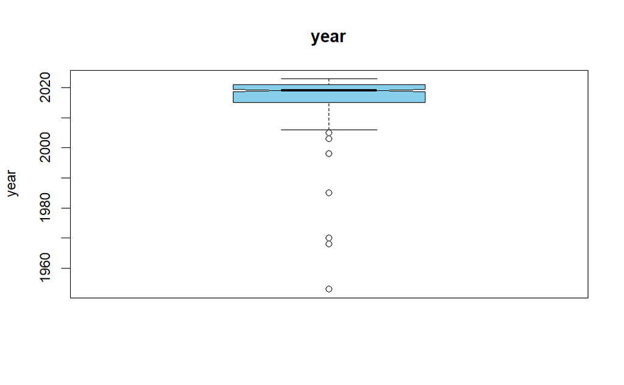

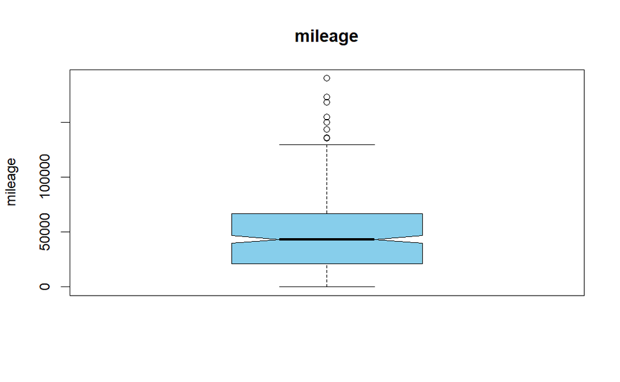

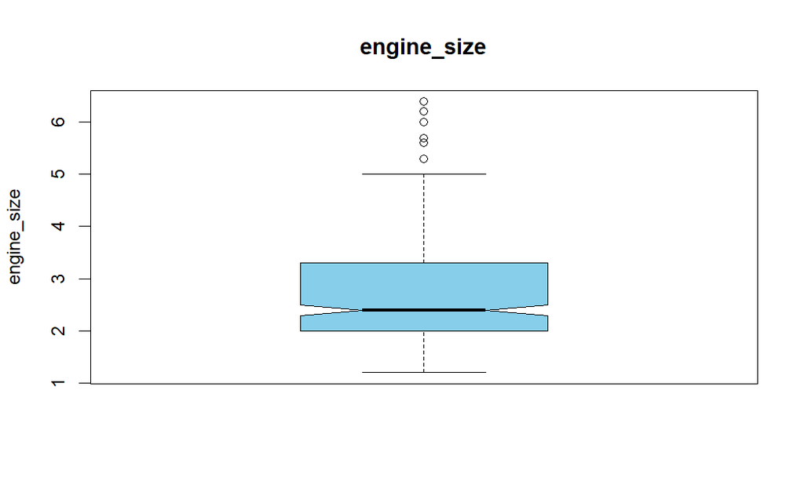

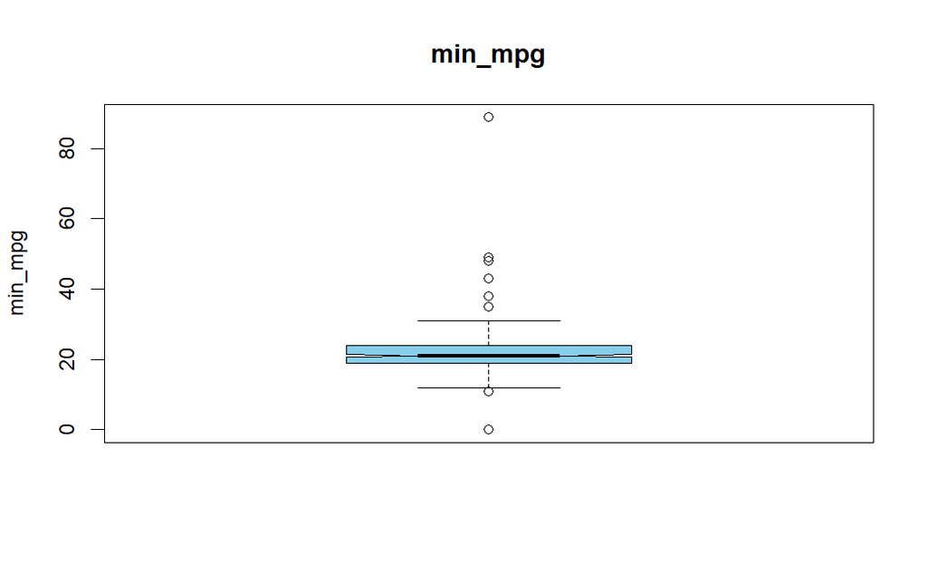

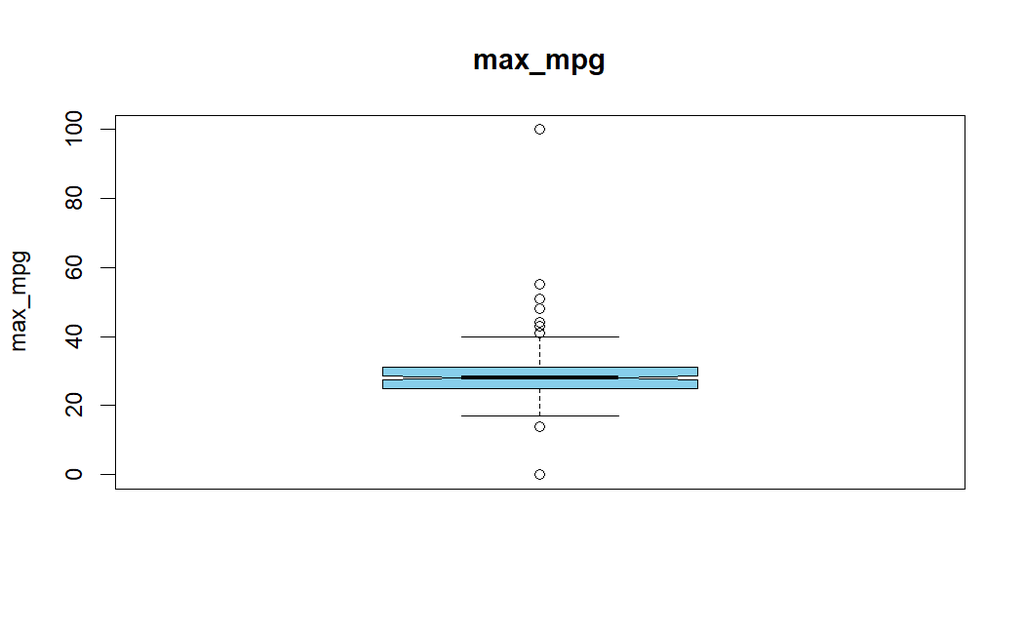

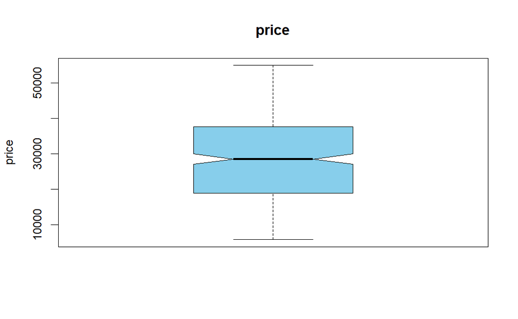

```r
#7.  Visualize outliers for numeric columns using boxplots

numerical_columns <- c("year", "mileage", "engine_size", "min_mpg", "max_mpg", "price")

#(i) BOXPLOT FOR NUMERICAL DATA
for (col in numerical_columns) {
  boxplot(mydf[[col]], main = col, ylab = col, col = "skyblue", border = "black", notch = TRUE)
}
```

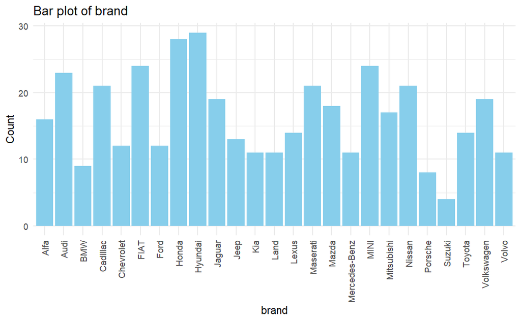

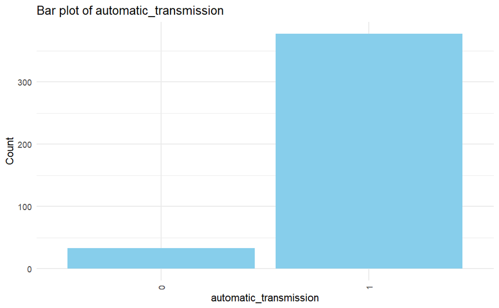

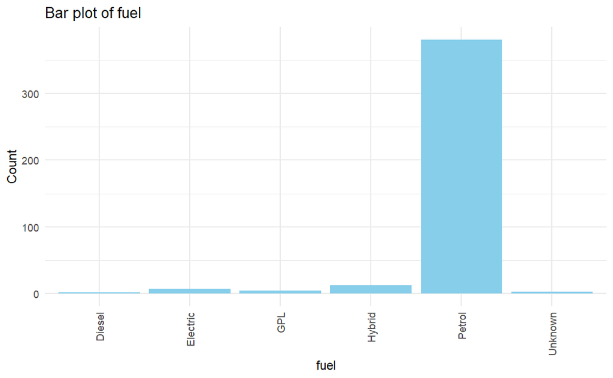

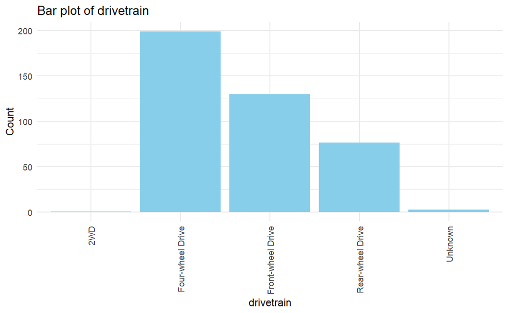

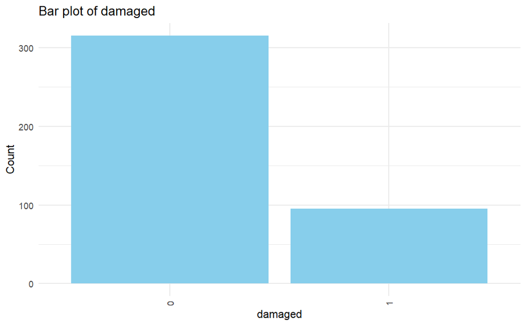

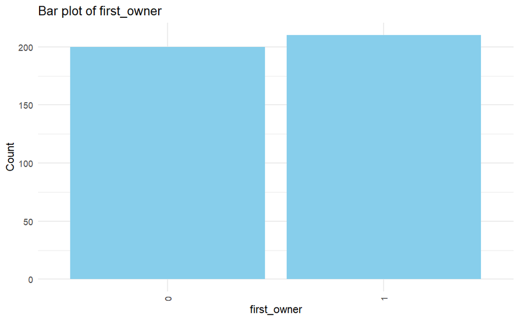

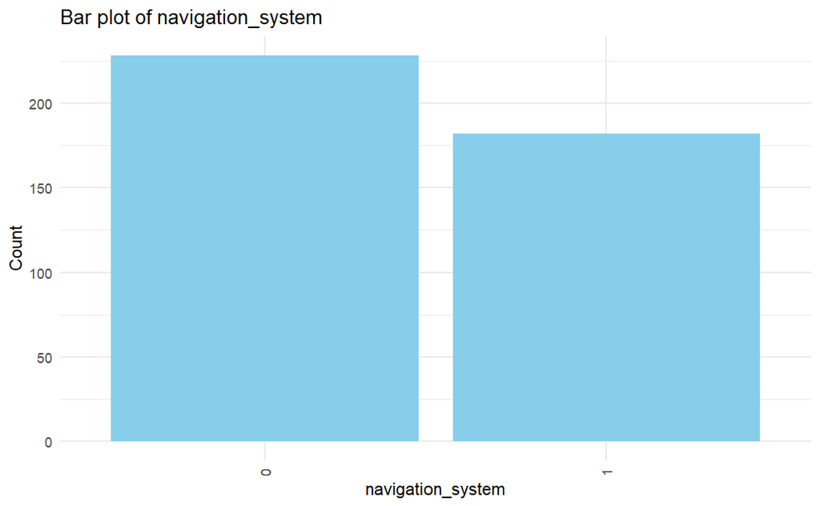

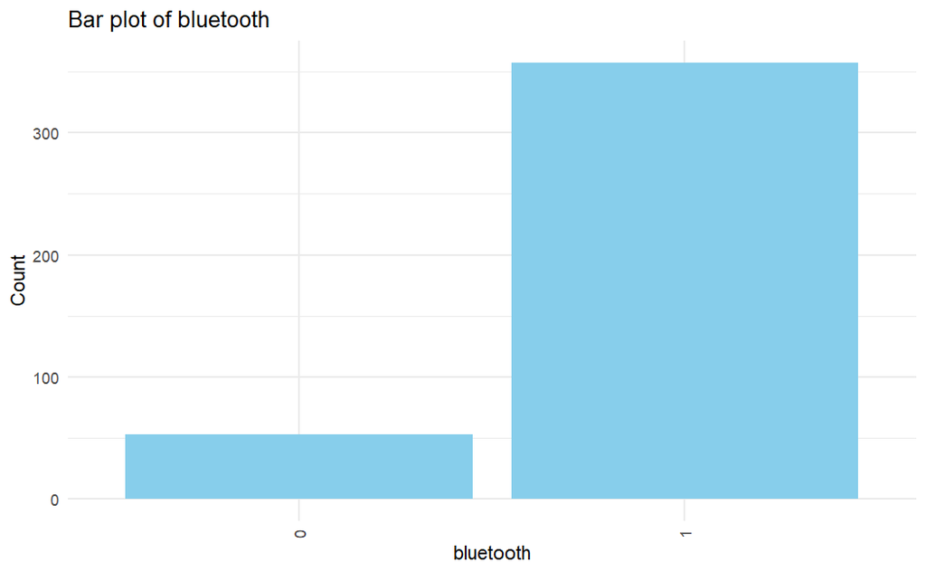

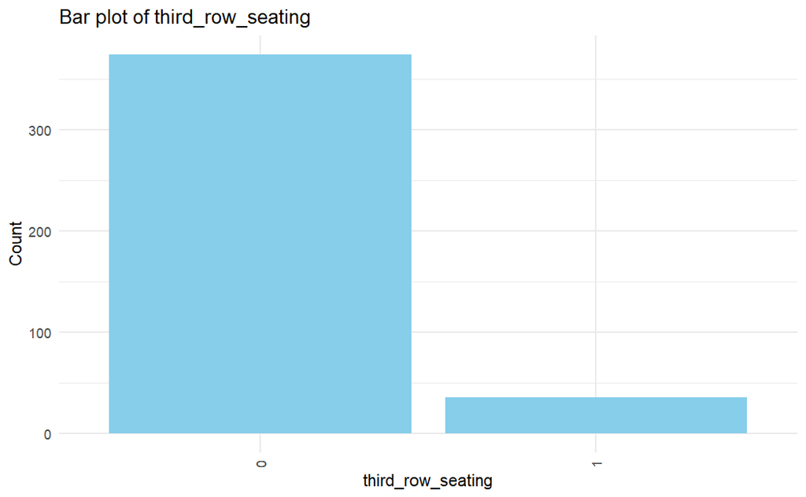

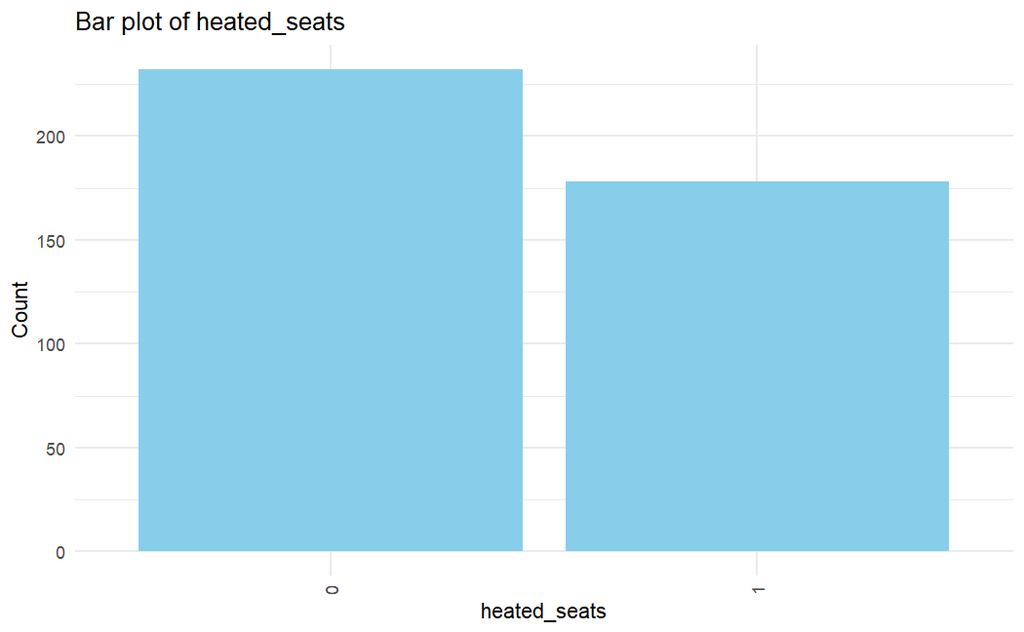

```r
#(ii) BAR PLOT FOR CATEGORICAL DATA
categorical_columns <- c("brand", "automatic_transmission", "fuel", "drivetrain", "damaged",
                         "first_owner", "navigation_system", "bluetooth", "third_row_seating",
                         "heated_seats")

for (col in categorical_columns) {
 p<-  ggplot(mydf, aes_string(x = col)) +
    geom_bar(fill = "skyblue") +
    labs(title = paste("Bar plot of", col), x = col, y = "Count") +
    theme_minimal() +
    theme(axis.text.x = element_text(angle = 90, vjust = 0.5, hjust=1))
 print(p)
}
```

```r
################################################
```

8. Detected Outliers of numerical by boxplots to understand descriptive statistics

```r
#8. OUTLIER DETECTION

# Using boxplot.stats to identify outliers
for (col in numerical_columns) {
  box_data <- boxplot.stats(mydf[[col]])
  outliers <- box_data$out
  cat("Outliers in", col, ":", outliers, "\n")
  if(length(outliers)==0){
    print("No outliers")
  }
}
```

```
Outliers in year : 1953 2005 1968 1998 1985 2005 1970 2003 2005
Outliers in mileage : 190312 143404 135750 154744 135629 168155 135201 150084 172844
Outliers in engine_size : 5.6 5.3 6.2 5.7 6.2 5.3 5.6 5.7 5.6 6 5.3 5.6 5.6 6.4 5.7 5.6 6.2
Outliers in min_mpg : 0 35 43 48 38 0 0 0 0 49 11 89 43 48 0
Outliers in max_mpg : 14 43 48 41 0 0 55 100 44 51 0
Outliers in price :
[1] "No outliers"
```

9. Correlation Analysis on all numerical columns using cor()

```r
#8. Cross-Field Analysis and Correlation
# Selecting numerical columns for correlation analysis


numeric_columns <- c("year", "mileage", "engine_size", "min_mpg", "max_mpg", "price")

# Subsetting the dataframe with only numeric columns
numeric_data <- mydf[, numeric_columns]

# Calculating correlation matrix
correlation_matrix <- cor(numeric_data)

# Formatting the correlation matrix for better spacing and alignment
formatted_matrix <- format(correlation_matrix, justify = "centre", digits = 2)

# Printing the formatted matrix
print(formatted_matrix)
```

```
            year       mileage    engine_size min_mpg    max_mpg    price
year        " 1.00000" "-0.31756" "-0.07766"  " 0.04943" " 0.01251" " 0.43858"
mileage     "-0.31756" " 1.00000" " 0.15340"  "-0.01624" "-0.00046" "-0.60776"
engine_size "-0.07766" " 0.15340" " 1.00000"  "-0.32737" "-0.38183" " 0.30279"
min_mpg     " 0.04943" "-0.01624" "-0.32737"  " 1.00000" " 0.93285" "-0.17538"
max_mpg     " 0.01251" "-0.00046" "-0.38183"  " 0.93285" " 1.00000" "-0.21746"
price       " 0.43858" "-0.60776" " 0.30279"  "-0.17538" "-0.21746" " 1.00000"
```

```r
#############################################################################
```

## 1.4 Data cleaning

# 2. Exploratory Data Analysis (EDA)

## 2.1 EDA plan

1. Data Familiarization:
   - To understand the structure, columns, and size of the dataset (str(), head(), summary()).
   - Descriptive Statistics: Calculate basic statistics (mean, median, min, max) for numeric variables.
2. Outlier Detection and Treatment:
   - Boxplots: Identify and handle outliers in numeric variables (remove, transform, or impute).
3. Univariate Analysis:
   - Bar Charts: Display frequency counts for categorical variables.
   - Boxplots: Identify outliers and understand variability in numeric variables.
4. Bivariate and Multivariate Analysis:
   - Correlation Analysis: Evaluate relationships between numeric variables using correlation matrices and scatterplots.
   - Scatterplots: Explore relationships between pairs of numeric variables.
   - Categorical Analysis: Compare categories across groups using heatmaps and bar plots.

4.Distribution of ‘price’: - Relationship between ‘price’ and other numerical variables using cor(). - ANOVA to explore how ‘price’ varies across categories of categorical predictors. - Visualisation with other variables

5. Distribution of ‘First Owner’:
   - Fishers test/Chi-sq to explore relationships with other categorical variables.
   - Logistic Regression to predict ‘first_owner’ based on other predictors.
   - Visualisation with other variables
6. Pattern Identification and Visualization:
   - Trends and Patterns: Identify trends, seasonality, or sequential data.
7. Summary and Documentation:
   - Summary Report: Summarize key findings, insights, and initial hypotheses.

## 2.2 EDA execution

1. Data Familiarization/descriptive summary

```r
#1. Data Familiarization
# Structure of the dataset

str(mydf)
```

```
'data.frame':   410 obs. of  16 variables:
 $ brand                 : Factor w/ 25 levels "Alfa","Audi",..: 2 12 7 11 1 20 4 4 9 1 ...
 $ year                  : num  2022 2021 2021 2022 2019 ...
 $ mileage               : num  7232 60942 45701 2963 47587 ...
 $ engine_size           : num  2 1.6 3 3.6 2 5.6 2 3.6 1.6 2 ...
 $ automatic_transmission: Factor w/ 2 levels "0","1": 2 2 2 2 2 2 2 2 2 2 ...
 $ fuel                  : Factor w/ 6 levels "Diesel","Electric",..: 5 5 5 5 5 5 5 5 5 5 ...
 $ drivetrain            : Factor w/ 5 levels "2WD","Four-wheel Drive",..: 2 3 2 2 2 4 3 3 3 2 ...
 $ min_mpg               : num  28 27 18 21 22 13 0 17 22 24 ...
 $ max_mpg               : num  36 37 24 29 29 18 14 25 25 33 ...
 $ damaged               : Factor w/ 2 levels "0","1": 1 2 1 1 1 1 1 2 1 1 ...
 $ first_owner           : Factor w/ 2 levels "0","1": 2 2 2 2 2 2 2 2 1 2 ...
 $ navigation_system     : Factor w/ 2 levels "0","1": 1 1 2 1 1 2 1 2 2 1 ...
 $ bluetooth             : Factor w/ 2 levels "0","1": 2 2 2 1 2 2 2 2 2 2 ...
 $ third_row_seating     : Factor w/ 2 levels "0","1": 1 1 2 1 1 2 1 1 1 1 ...
 $ heated_seats          : Factor w/ 2 levels "0","1": 2 1 2 1 1 1 1 1 2 1 ...
 $ price                 : num  37500 15990 46290 44290 28990 ...
```

```r
# Loop through each column and output summary
for (col in names(mydf)) {
  cat("Summary for column:", col, "\n")
  print(summary(mydf[[col]]))
  cat("\n")
}
```

```
Summary for column: brand
         Alfa          Audi           BMW      Cadillac     Chevrolet          FIAT          Ford
           16            23             9            21            12            24            12
        Honda       Hyundai        Jaguar          Jeep           Kia          Land         Lexus
           28            29            19            13            11            11            14
     Maserati         Mazda Mercedes-Benz          MINI    Mitsubishi        Nissan       Porsche
           21            18            11            24            17            21             8
       Suzuki        Toyota    Volkswagen         Volvo
            4            14            19            11

Summary for column: year
   Min. 1st Qu.  Median    Mean 3rd Qu.    Max.
   1953    2015    2019    2017    2021    2023

Summary for column: mileage
   Min. 1st Qu.  Median    Mean 3rd Qu.    Max.
      0   21328   43286   48382   66593  190312

Summary for column: engine_size
   Min. 1st Qu.  Median    Mean 3rd Qu.    Max.
   1.20    2.00    2.40    2.65    3.30    6.40

Summary for column: automatic_transmission
  0   1
 33 377

Summary for column: fuel
  Diesel Electric      GPL   Hybrid   Petrol  Unknown
       2        7        5       13      380        3

Summary for column: drivetrain
              2WD  Four-wheel Drive Front-wheel Drive  Rear-wheel Drive           Unknown
                1               199               130                77                 3

Summary for column: min_mpg
   Min. 1st Qu.  Median    Mean 3rd Qu.    Max.
   0.00   19.00   21.00   21.37   24.00   89.00

Summary for column: max_mpg
   Min. 1st Qu.  Median    Mean 3rd Qu.    Max.
```

[output cut: 14 more lines]

```
Summary for column: bluetooth
  0   1
 53 357

Summary for column: third_row_seating
  0   1
374  36

Summary for column: heated_seats
  0   1
232 178

Summary for column: price
   Min. 1st Qu.  Median    Mean 3rd Qu.    Max.
   5850   18991   28512   28399   37564   54995
```

```r
#############################
```

2. Outlier Detection and Treatment

```r
#2 Outliers Detection and Correction
  # Visualize outliers for numeric columns using boxplots
numerical_columns <- c("year", "mileage", "engine_size", "min_mpg", "max_mpg", "price")


# Function to calculate the distance of outliers from the median
calculate_distance_from_median <- function(column) {
  median_val <- median(column)
  distances <- abs(column - median_val)
  return(distances)
}

# Using boxplot.stats to identify outliers and rank them based on distance from median
for (col in numerical_columns) {
  box_data <- boxplot.stats(mydf[[col]])
  outliers <- box_data$out

  distances_from_median <- calculate_distance_from_median(outliers)

  # Rank outliers by their distance from the median in descending order
  outliers_ranked <- outliers[order(distances_from_median, decreasing = TRUE)]

  cat("Outliers in", col, ":", outliers_ranked, "\n")
  if(length(outliers_ranked) == 0) {
    print("No outliers")
  }
}
```

```
Outliers in year : 1953 1968 1970 1985 2005 2005 2005 2003 1998
Outliers in mileage : 190312 172844 168155 135201 135629 135750 143404 154744 150084
Outliers in engine_size : 6.4 6.2 6.2 6.2 6 5.3 5.3 5.3 5.7 5.7 5.7 5.6 5.6 5.6 5.6 5.6 5.6
Outliers in min_mpg : 89 0 0 0 0 0 0 11 49 48 48 43 43 38 35
Outliers in max_mpg : 100 0 0 0 14 55 51 48 41 44 43
Outliers in price :
[1] "No outliers"
```

```r
result <- mydf[mydf$min_mpg == 89, ]
print(result)
```

|  | brand | year | mileage | engine_size | automatic_transmission | fuel | drivetrain | min_mpg | max_mpg | damaged | first_owner | navigation_system | bluetooth | third_row_seating | heated_seats | price |
| --- | --- | --- | --- | --- | --- | --- | --- | --- | --- | --- | --- | --- | --- | --- | --- | --- |
| 18473 | Audi | 2022 | 8036 | 2.4 | 1 | Petrol | Four-wheel Drive | 89 | 100 | 0 | 1 | 0 | 1 | 0 | 1 | 51000 |

```r
result <- mydf[mydf$max_mpg == 100, ]
print(result)
```

|  | brand | year | mileage | engine_size | automatic_transmission | fuel | drivetrain | min_mpg | max_mpg | damaged | first_owner | navigation_system | bluetooth | third_row_seating | heated_seats | price |
| --- | --- | --- | --- | --- | --- | --- | --- | --- | --- | --- | --- | --- | --- | --- | --- | --- |
| 18473 | Audi | 2022 | 8036 | 2.4 | 1 | Petrol | Four-wheel Drive | 89 | 100 | 0 | 1 | 0 | 1 | 0 | 1 | 51000 |

```r
#result is 1 row, imputing it with median

median_min_mpg <- median(mydf$min_mpg, na.rm = TRUE)
median_max_mpg <- median(mydf$max_mpg, na.rm = TRUE)
mydf$min_mpg[mydf$min_mpg == 89] <- median_min_mpg
mydf$max_mpg[mydf$max_mpg == 100] <- median_max_mpg

###########################################################################################
```

3. Univariate Analysis: (i) Bar Chartsfor categorical variables. (ii) Boxplots for numeric variables.

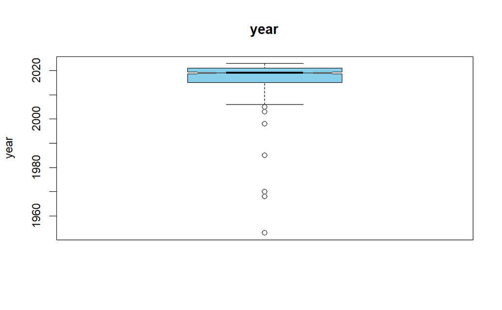

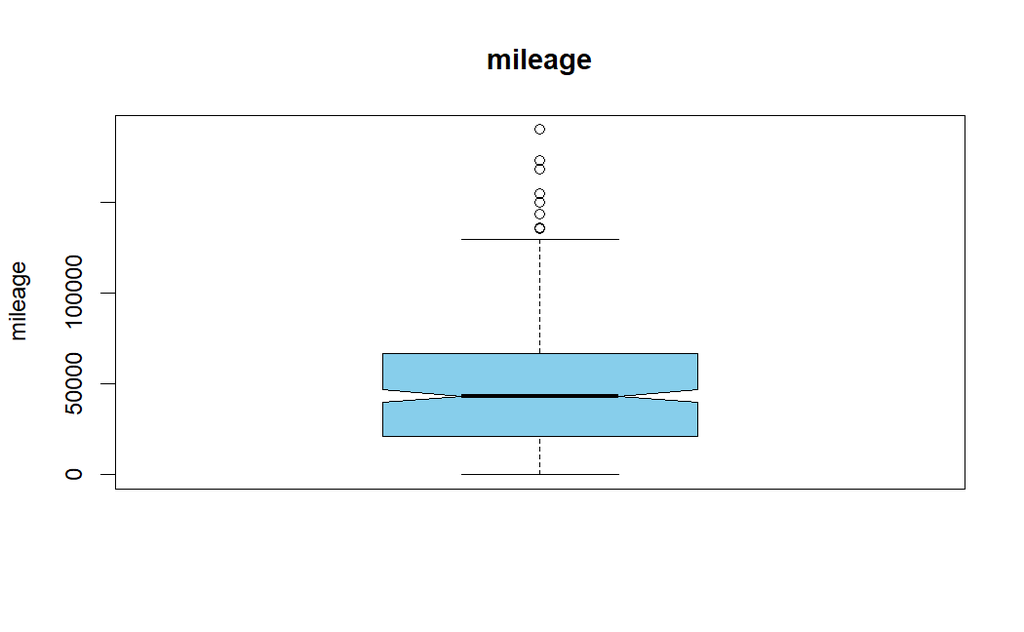

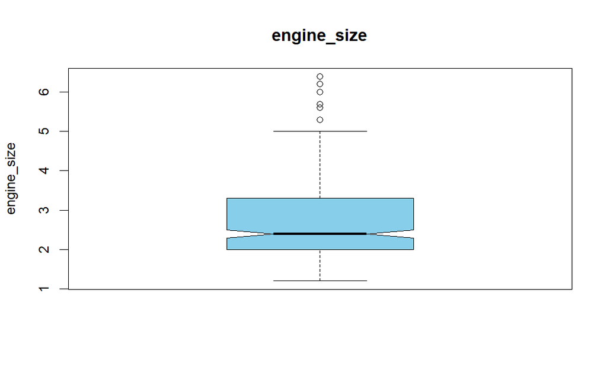

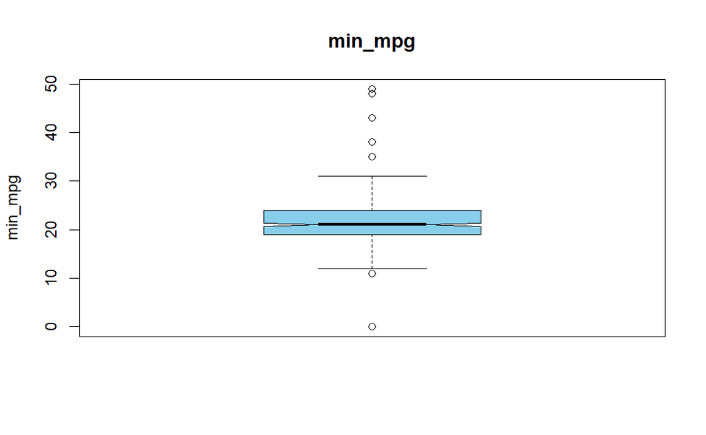

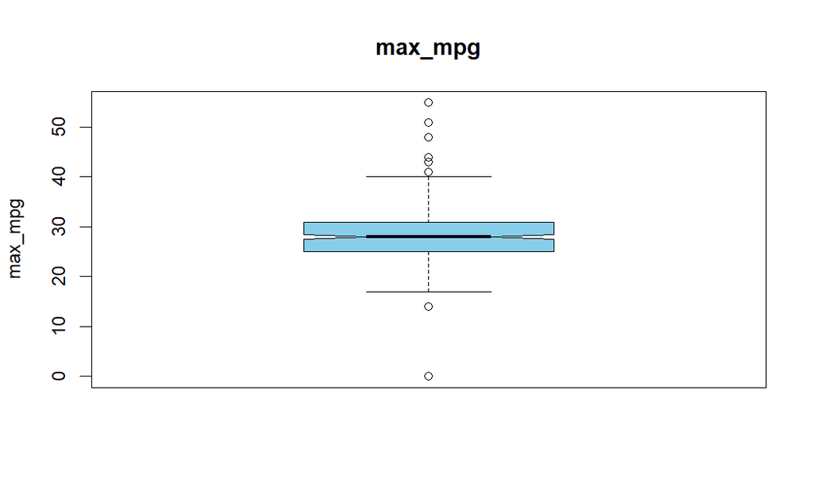

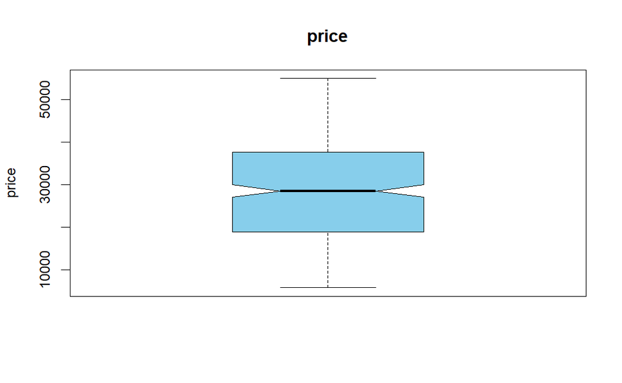

```r
#3. Univariate Analysis

##################### NUMERIC ################


numerical_cols <- c("year", "mileage", "engine_size", "min_mpg", "max_mpg", "price")
categorical_cols <- c("brand", "automatic_transmission", "fuel", "drivetrain", "damaged",
                         "first_owner", "navigation_system", "bluetooth", "third_row_seating",
                         "heated_seats")


# Histograms for numerical variables (separately)
for (col in numerical_cols) {
  boxplot(mydf[[col]], main = col, ylab = col, col = "skyblue", border = "black", notch = TRUE)
}
```